# Skagit Creel Analysis

Thomas Buehrens, Kale Bentley, Andrew Fowler & Amy Edwards

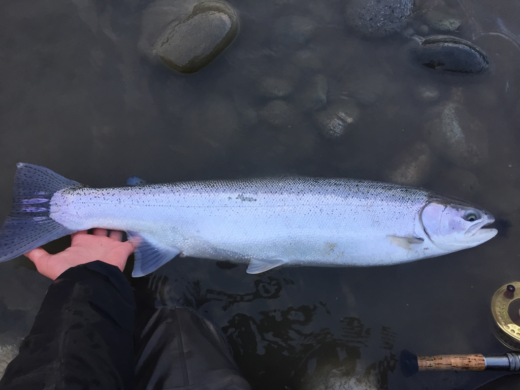

# Overview

The purpose of this page is to: 1) record the steps and code necessary to reproduce the Skagit steelhead fishery creel analysis and fishery impact monitoring for 2021. 2) provide a pre-season comparison of planned Skagit steelhead sport fishery impacts with allowable impacts based on the Skagit Resource Management Plan. 3) provide in-season tracking of Skagit steelhead sport fishery impacts relative to allowable impacts based on the Skagit Resource Management Plan.

# Disclaimer

Contents of this document should be treated as preliminary and are subject to change. While every effort has been made to ensure the accuracy of data and modeling here, some numbers may change. Particularly in-season catch and effort estimates may change as additional data becomes available, and as data errors are corrected.

# Running the analysis yourself

To run the analysis yourself, download the repository here [**(link)**](https://github.com/tbuehrens/CreelAnalysis/) and follow instructions below. The following subsections detail reproducing the analysis and refer to code chunks in the .RMD file that created this page: [**(link)**](https://github.com/tbuehrens/CreelAnalysis/blob/main/Skagit_Analysis.Rmd). If only interested in results, the pre-season fishery plan and the inseason fishery results, skip down to pre-season fishery plan section. If interested in running the analysis, the subsections below provide brief descriptions of what these code chunks in the .RMD file do.

### Requirements

all analyses require R software [**(link)**](https://cran.r-project.org/) (v4.0+) for data retrieval, data processing, and summarizing model results, and Stan software [**(link)**](https://github.com/stan-dev/rstan/wiki/RStan-Getting-Started/) for Hamiltonian Monte Carlo (HMC) simulation. Additionally, for Stan to work, rtools must also be installed: [**(link)**](https://cran.r-project.org/bin/windows/Rtools/).

### Functions

We also need a couple of helper functions which we will load from the functions folder, which we will load using the chunk of code with this heading in the RMD file.

### Packages

In addition to purrr, we also need a few packages that are not included with the base installation of R, so we begin by installing them (if necessary) and then loading them using using the chunk of code with this heading in the RMD file.

### User inputs

Here we will specify user inputs like the file names of the data, the species, and stream name we would like to analyze data for, etc. using the chunk of code with this heading in the RMD file.

### Data Preparation

Here we will load and format the data for the analysis using the chunk of code with this heading in the RMD file.

### Run Analysis

Here we will run the in-season analysis of creel data to estimate CPUE, effort, and catch using the chunk of code with this heading in the RMD file.

### Summarize and Save Results

Here we will summarize and save results of the in-season analysis of creel data to estimate CPUE, effort, and catch using the chunk of code with this heading in the RMD file.

# Pre-season Fishery Planning

### Fishery Impacts Relative to RMP Limits: Preseason Plan

Here we will compare the planned sport fishery catch, assuming 10% C&R mortality, with the forecasted run size and the RMP mortality limits.

First, the allowable harvest rates in the RMP are:

Table 1. Allowable Harvest Rates, Skagit RMP

| MinRunsize | MaxRunsize | Exploitation Rate |
| --- | --- | --- |
| 0 | 4000 | 0.04 |
| 4001 | 6000 | 0.10 |
| 6001 | 8000 | 0.20 |
| 8001 | 1000000 | 0.25 |

Second, the run size forecast is below. For more details on how this forecast was developed, see this GitHub repository, jointly developed by the Skagit Co-Managers & WDFW: [**(link)**](https://github.com/casruff/Skagit-River-Steelhead-Forecast). The final forecast document including testing of multiple models and development of an ensemble forecast is found in this pdf:[**(link)**](https://github.com/tbuehrens/Skagit-River-Steelhead-Forecast/blob/master/analysis/App_2_Model_fitting_forecast_2020_2021_step_head_fcst.pdf). A published scientific paper describing the methods may be found here [**(link)**](https://besjournals.onlinelibrary.wiley.com/doi/abs/10.1111/1365-2664.13789).

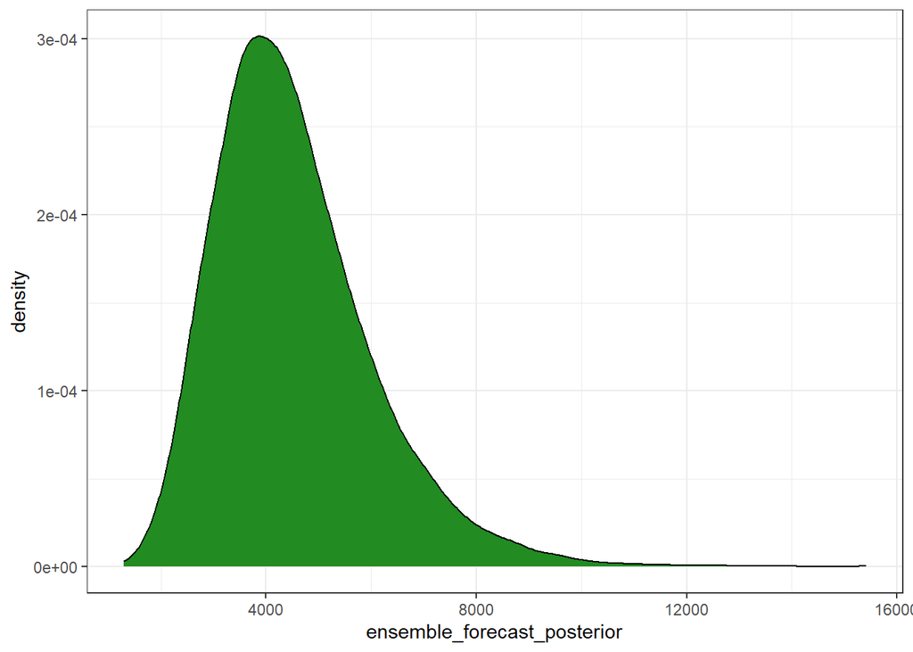

Figure 1. Skagit Steelhead Run size Forecast

Table 2. Runsize Forecast

| Run Size | Quantile |
| --- | --- |
| 2283.296 | 0.025 |
| 3470.260 | 0.250 |
| 4297.101 | 0.500 |
| 5322.188 | 0.750 |
| 8165.904 | 0.975 |

The allowable harvest, according to the RMP, is the number of fish that may be killed by the combined sport and tribal fisheries. However, as seen above, this number depends on the run-size, which is not known until after the fishing season when escapement is estimated. However, based on the pre-season forecast run size, we can estimate what the allowable harvest will be by combining the forecast run size, including its uncertainty, with the harvest rate matrix prescribed by the RMP. We can then plot the probability that the true allowable harvest (once it is known after the season) will exceed a range of values.

For example, in 2021 there is a greater than 90% chance that the true allowable harvest based on the true run size and the harvest matrix, will exceed 100 fish. There is a 50% chance that the allowable harvest will exceed 430 fish (10% of the best estimate of the runsize from the forecast), and a very small chance the allowable harvest will be greater than 2000 fish:

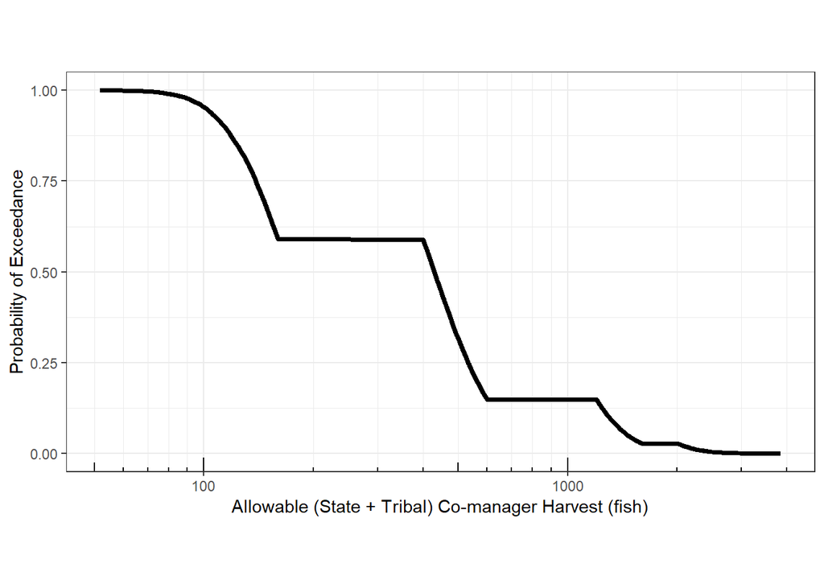

Figure 2. Probability that the allowable harvest exceeds a particular number of fish based on the RMP. Note the log10 scale on the x-axis.

Given the uncertainty in what the allowable harvest will turn out to be, managers must balance the risk of exceeding the allowable harvest with cost of erring so heavily on the side of conservation (to ensure the allowable harvest is not exceeded) that no fishery is allowed at all. To assist with this task, managers can plan a fishery to harvest a particular number of fish (which itself may be estimated with uncertainty) and then calculate the probability that the allowable harvest will turn out to have been exceeded if the planned fishery is implemented.

For example, in 2021, a 4-day a week fishery was planned with a total harvest (wild fish handled * assumed 10% C&R mortality rate) of 76 fish. This would translate to 18% of the allowable (sport + tribal) harvest under the RMP if the true allowable harvest is 430, at which point the exceedence probability is 50%. The exceedence probability is greater than 50% when the percentage of allowable harvest used is less than 18%, indicating it is more probable than not that the planned sport fishery will harvest a greater perecentage of the allowable harvest. The exceedence probability is less than 50% when the percentage of allowable harvest used is greater than 18%, indicating it is more probable than not that the planned fishery will not use this much of the allowable harvest:

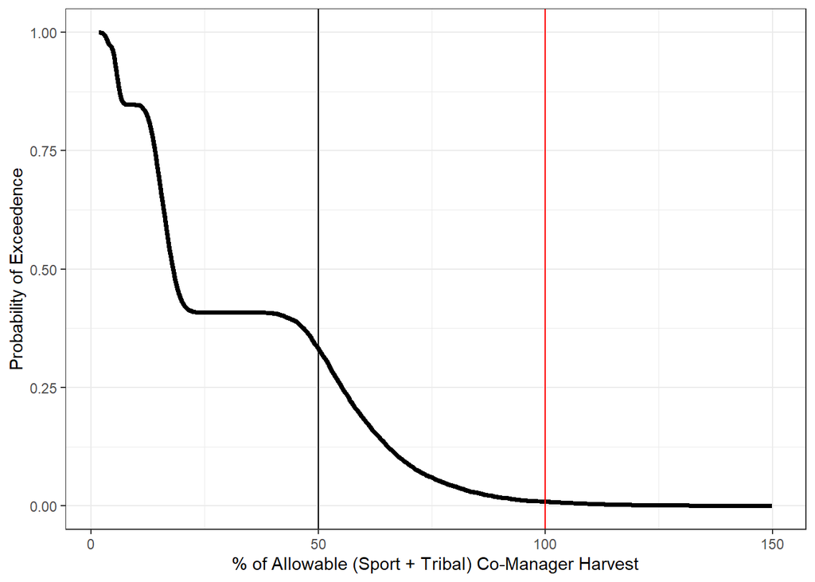

Figure 3. Probability that the pre-season planned sport fishery harvest exceeds X % of the allowable harvest under the RMP. Vertical lines denote 50% of the allowable harvest, which is shared between the state and tribes, and 100% of the allowable harvest

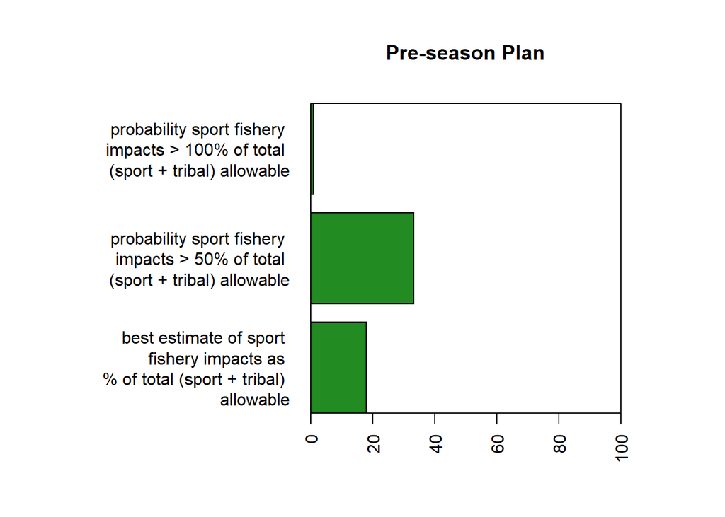

Figure 4. Pre-season Planned Probability that the sport fishery harvest exceeds 50 and 100 % of the allowable harvest under the RMP, as well as the best estimate of the percentage of allowable impacts the sport fishery will use

# In-season Fishery Results

In this section we will use data coming in from the creel survey to estimate the season total as well as daily catch and effort, and the daily catch per unit effort (CPUE).

### Season Total Effort (hours) and Catch (fish)

This table and the figures below it show the posterior distribution for season total catch and effort. The “best” estimate is the 50th percentile (median):

Table 3. Total Catch and Effort

| Variable | Mean | 2.5% | 25% | 50% | 75% | 97.5% | CV |
| --- | --- | --- | --- | --- | --- | --- | --- |
| Total_season_catch | 1106 | 953 | 1048 | 1092 | 1153 | 1287 | 0.1 |
| Total_season_effort | 40190 | 37424 | 39096 | 40110 | 41188 | 43323 | 0.0 |

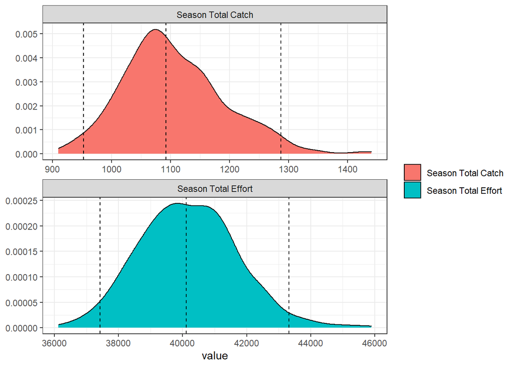

Figure 5. Season total catch (fish) and effort (hrs). Dashed lines show posterior medians 95% CI

### Daily Catch, Effort, and Catch Per Unit Effort (CPUE) (fish)

He we estimate the daily catch, effort, and CPUE. The lines are the “best” estimates and the shading shows the 95% credible intervals.

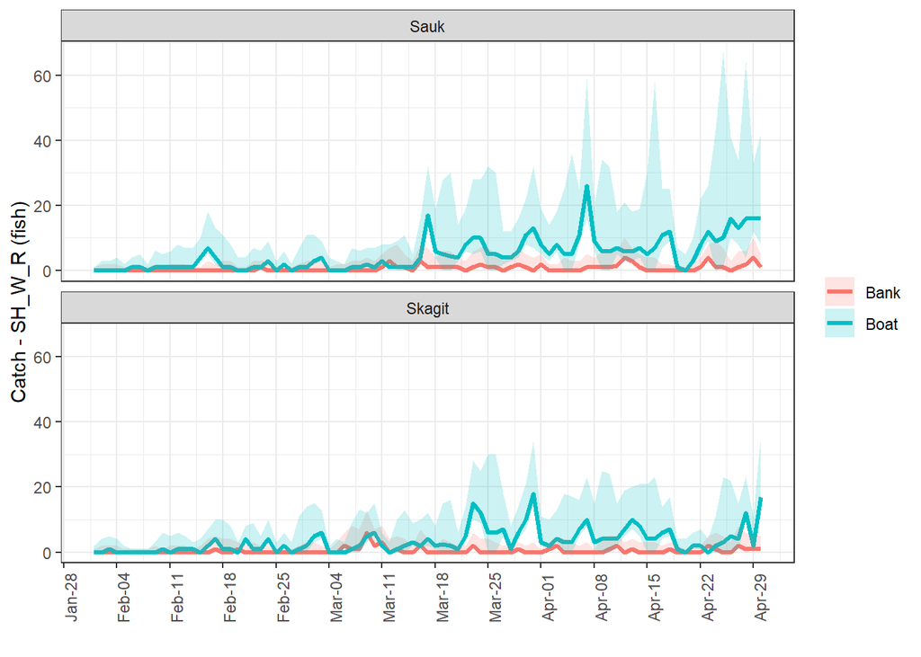

Figure 6. Daily catch. Lines are posterior medians and shading shows 95% CI

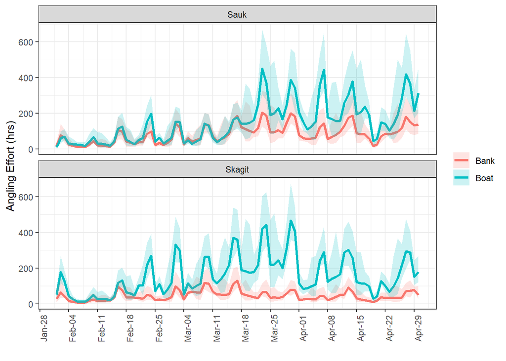

Figure 7. Daily effort. Lines are posterior medians and shading shows 95% CI

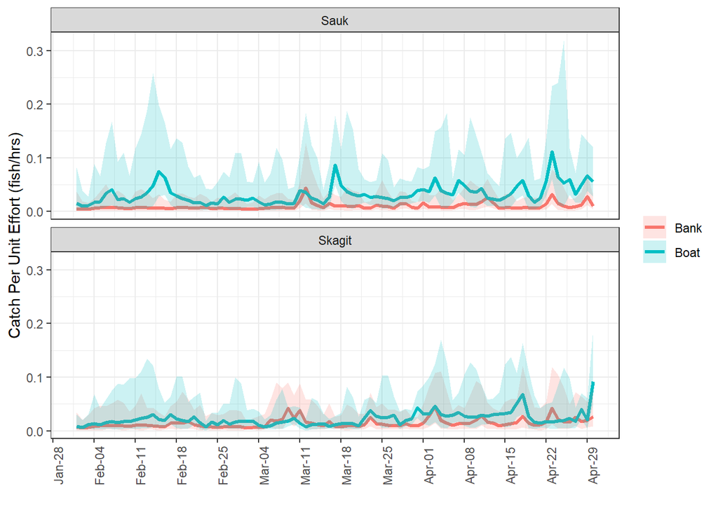

Figure 8. Daily CPUE. Lines are posterior medians and shading shows 95% CI

### Inseason Impact Monitoring: Fishery Impacts Relative to RMP Limits

Here, we compare the actual in-season estimated sport fishery catch, assuming 10% C&R mortality, with the allowable harvest estimated from the forecasted run size and the RMP mortality limits, to estimate the probability that the allowable harvest has been exceeded by the actual fishery (as opposed to the pre-season plan that we looked at previously). Early in the season when little catch has occurred, the probability that the allowable harvest has been exceeded is low, but increases as the season goes on. This analyis enables an in-season quantification of risk by managers, which may be helpful in decision-making:

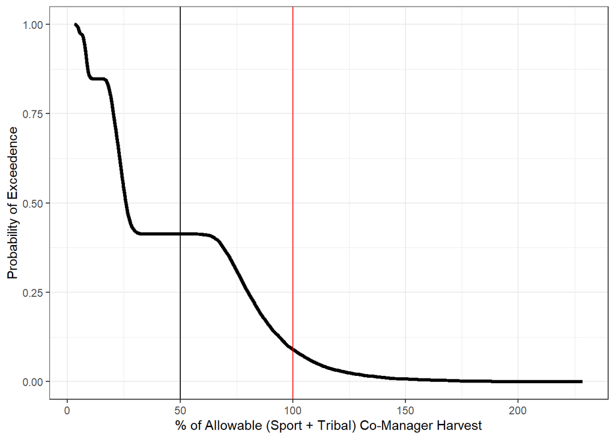

Figure 9. Probability that the actual in-season sport fishery harvest exceeds X % of the allowable harvest under the RMP. Vertical lines denote 50% of the allowable harvest, which is shared between the state and tribes, and 100% of the allowable harvest

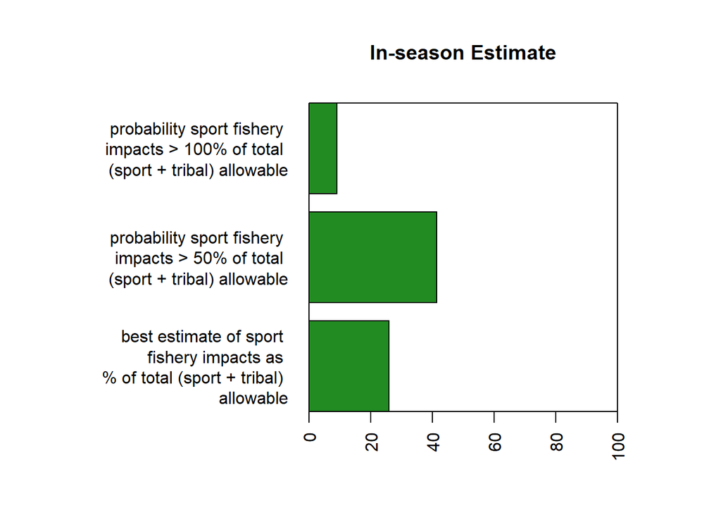

Figure 10. Probability that the sport fishery harvest exceeds 50 and 100 % of the allowable harvest under the RMP, as well as the best estimate of the percentage of allowable impacts the sport fishery will use